# Project_6_Material_mfg

### Project-6

### Domain : Material Manufacturing

Description : Concrete is the most important material in civil engineering. The concrete compressive strength is a highly nonlinear function of age and ingredients. These ingredients include cement, blast furnace slag, fly ash, water, superplasticizer, coarse aggregate, and fine aggregate

```
The data has 8 quantitative input variables, and 1 quantitative output variable, and 1030 instances (observations)
```

======================================================================================================

### Importing Libraries

```python
import numpy as np
import pandas as pd
import matplotlib.pyplot as plt
import seaborn as sns

%matplotlib inline

import warnings
warnings.filterwarnings('ignore')
```

```python
from sklearn.model_selection import train_test_split

from sklearn.preprocessing import StandardScaler
from sklearn.preprocessing import normalize
```

```python
from sklearn.linear_model import LinearRegression
from sklearn.ensemble import RandomForestRegressor
from sklearn.tree import DecisionTreeRegressor
from sklearn.svm import SVR
from sklearn.gaussian_process import GaussianProcessRegressor
from sklearn.ensemble import GradientBoostingRegressor
from sklearn.ensemble import AdaBoostRegressor
```

```python
from sklearn.model_selection import RandomizedSearchCV
from sklearn.model_selection import GridSearchCV
```

```python
from sklearn import metrics
from sklearn.metrics import accuracy_score
from sklearn.metrics import mean_squared_error
from sklearn.metrics import mean_absolute_error
from sklearn.metrics import r2_score
from sklearn.metrics import roc_auc_score
```

```python
from sklearn.utils import resample
```

### Load Dataset into DataFrame

```python
conDF = pd.read_csv('concrete.csv')
```

```python
conDF.head(5)
```

|  | cement | slag | ash | water | superplastic | coarseagg | fineagg | age | strength |
| --- | --- | --- | --- | --- | --- | --- | --- | --- | --- |
| 0 | 141.3 | 212.0 | 0.0 | 203.5 | 0.0 | 971.8 | 748.5 | 28 | 29.89 |
| 1 | 168.9 | 42.2 | 124.3 | 158.3 | 10.8 | 1080.8 | 796.2 | 14 | 23.51 |
| 2 | 250.0 | 0.0 | 95.7 | 187.4 | 5.5 | 956.9 | 861.2 | 28 | 29.22 |
| 3 | 266.0 | 114.0 | 0.0 | 228.0 | 0.0 | 932.0 | 670.0 | 28 | 45.85 |
| 4 | 154.8 | 183.4 | 0.0 | 193.3 | 9.1 | 1047.4 | 696.7 | 28 | 18.29 |

```python
conDF.info()
```

```
<class 'pandas.core.frame.DataFrame'>
RangeIndex: 1030 entries, 0 to 1029
Data columns (total 9 columns):
cement          1030 non-null float64
slag            1030 non-null float64
ash             1030 non-null float64
water           1030 non-null float64
superplastic    1030 non-null float64
coarseagg       1030 non-null float64
fineagg         1030 non-null float64
age             1030 non-null int64
strength        1030 non-null float64
dtypes: float64(8), int64(1)
memory usage: 72.5 KB
```

There are 1030 rows and 9 columns in the dataset. All the features are numeric in nature.

```python
Shape=conDF.shape
```

```python
print ("Total rows in Dataset    : ", Shape[0])
print ("Total columns in Dataset : ", Shape[1])
```

```
Total rows in Dataset    :  1030
Total columns in Dataset :  9
```

```python
conDF[~conDF.applymap(np.isreal).all(1)]
```

|  | cement | slag | ash | water | superplastic | coarseagg | fineagg | age | strength |
| --- | --- | --- | --- | --- | --- | --- | --- | --- | --- |

There are no non-numeric characters in each row. np.isreal checks and returns the results as a boolean array.

```python
conDF.describe().T
```

|  | count | mean | std | min | 25% | 50% | 75% | max |
| --- | --- | --- | --- | --- | --- | --- | --- | --- |
| cement | 1030.0 | 281.167864 | 104.506364 | 102.00 | 192.375 | 272.900 | 350.000 | 540.0 |
| slag | 1030.0 | 73.895825 | 86.279342 | 0.00 | 0.000 | 22.000 | 142.950 | 359.4 |
| ash | 1030.0 | 54.188350 | 63.997004 | 0.00 | 0.000 | 0.000 | 118.300 | 200.1 |
| water | 1030.0 | 181.567282 | 21.354219 | 121.80 | 164.900 | 185.000 | 192.000 | 247.0 |
| superplastic | 1030.0 | 6.204660 | 5.973841 | 0.00 | 0.000 | 6.400 | 10.200 | 32.2 |
| coarseagg | 1030.0 | 972.918932 | 77.753954 | 801.00 | 932.000 | 968.000 | 1029.400 | 1145.0 |
| fineagg | 1030.0 | 773.580485 | 80.175980 | 594.00 | 730.950 | 779.500 | 824.000 | 992.6 |
| age | 1030.0 | 45.662136 | 63.169912 | 1.00 | 7.000 | 28.000 | 56.000 | 365.0 |
| strength | 1030.0 | 35.817961 | 16.705742 | 2.33 | 23.710 | 34.445 | 46.135 | 82.6 |

1. Statistical description shows the all features are numeric and displays the mean, median and standard deviation of each. 2. slag, ash and age has mean value greater than 50% value. Indicates right side skewness in data. 3. Also slag, ash and superplastic has the min value of zero. Which cannot be composition in cement. 4. Colunm water has std (21.35) < min (121.80), doubt it considering this for the further analysis. 5. Data does not have missing values or any special characters, but many values are zero, which has to be treated.

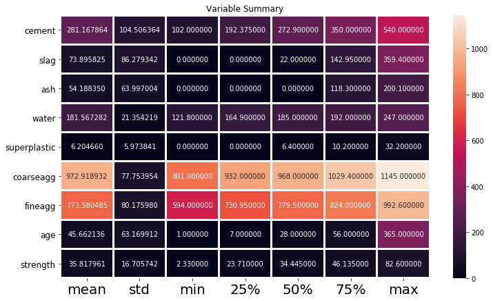

```python
plt.figure(figsize=(12,7))
sns.heatmap(conDF.describe()[1:].T,annot=True,fmt="f",linewidth=2)
plt.xticks(fontsize=20)
plt.yticks(fontsize=12)
plt.title("Variable Summary")
plt.show()
```

```python
conDF[(conDF['age'] > 365) | (conDF['age'] < 1)]
```

|  | cement | slag | ash | water | superplastic | coarseagg | fineagg | age | strength |
| --- | --- | --- | --- | --- | --- | --- | --- | --- | --- |

Checking the age boundaries in dataset

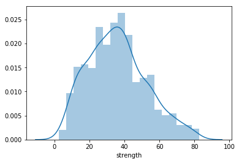

```python
sns.distplot(conDF['strength'])
```

1. This strength variable has almost normal distribution.

```python
print ("Skewness of strngth : ", conDF['strength'].skew())
```

```
Skewness of strngth :  0.41697728841071807
```

1. The skewness is very little on the positive side and < 0.5.

```python
#1. Deliverable -1  (Exploratory data quality report reflecting the following)
#a. Univariate analysis
#    i. Univariate analysis – data types and description of the independent attributes which should include
#       (name, meaning, range of values observed, central values (mean and median), standard deviation and quantiles,
#       analysis of the body of distributions / tails,  missing values, outliers
#b. Multivariate analysis
#    i. Bi-variate analysis between the predictor variables and between the predictor variables and target column. Comment on your findings in terms of their relationship and degree of relation if any. Presence of leverage points. Visualize the analysis using boxplots and pair plots, histograms or density curves. Select the most appropriate attributes
#c. Strategies to address the different data challenges such as data pollution, outliers and missing values
```

```python
def outlier_cnt_low_high(df, col_name):
    df_low_outlier = 0
    df_high_outlier = 0
    msg = ""
    q1 = df[col_name].quantile(0.25)
    q3 = df[col_name].quantile(0.75)
    iqr = q3-q1 #Interquartile range
    fence_low  = q1-1.5*iqr
    fence_high = q3+1.5*iqr
    df_low_outlier = df[col_name].loc[(df[col_name] < fence_low)].count()
    df_high_outlier = df[col_name].loc[(df[col_name] > fence_high)].count()

    if df_low_outlier > 0 and df_high_outlier > 0 :
        msg = "Both Low and Upper Outlier exists"
    elif df_low_outlier == 0 and df_high_outlier == 0 :
        msg = "No outliers exists"
    elif df_low_outlier > 0 and df_high_outlier == 0 :
        msg = "Only lower limit outlier exists"
    elif df_low_outlier == 0 and df_high_outlier > 0 :
        msg = "Only upper limit outlier exists"

    return df_low_outlier, df_high_outlier, msg
```

```python
### Uni-variate analysis which includes (name, range of values, central values (mean/median), standard deviation, quartiles,
### analysis of the body of distribution / tails, missing values, ouliers)
def univariate_analysis(df, col_name):

    low_cnt, upper_cnt, msg = outlier_cnt_low_high(df, col_name)

    analysisDF = pd.DataFrame({'column':col_name.upper(),
                               'min_value':df[col_name].min(),
                               'max_value':df[col_name].max(),
                               'mean':df[col_name].mean(),
                               'median':df[col_name].median(),
                               'std':df[col_name].std(),
                               '25th_quartile':df[col_name].quantile(.25),
                               '50th_quartile':df[col_name].quantile(.50),
                               '75th_quartile':df[col_name].quantile(.75),
                               'skew_tails':df[col_name].skew(),
                               'missing_val':df[col_name].isnull().values.any(),
                               'outliers':msg},index=[0])
    print (analysisDF)
```

```python
for col in  conDF.columns:
    univariate_analysis(conDF, col)
    #f, axes = plt.subplots( figsize=(8, 10), sharex=True)
    #sns.boxplot(conDF[col])
    print ("\n==========================================")
```

```
   column  min_value  max_value        mean  median         std  \
0  CEMENT      102.0      540.0  281.167864   272.9  104.506364

   25th_quartile  50th_quartile  75th_quartile  skew_tails  missing_val  \
0        192.375          272.9          350.0    0.509481        False

             outliers
0  No outliers exists

==========================================
  column  min_value  max_value       mean  median        std  25th_quartile  \
0   SLAG        0.0      359.4  73.895825    22.0  86.279342            0.0

   50th_quartile  75th_quartile  skew_tails  missing_val  \
0           22.0         142.95    0.800717        False

                          outliers
0  Only upper limit outlier exists

==========================================
  column  min_value  max_value      mean  median        std  25th_quartile  \
0    ASH        0.0      200.1  54.18835     0.0  63.997004            0.0

   50th_quartile  75th_quartile  skew_tails  missing_val            outliers
0            0.0          118.3    0.537354        False  No outliers exists

==========================================
  column  min_value  max_value        mean  median        std  25th_quartile  \
0  WATER      121.8      247.0  181.567282   185.0  21.354219          164.9

   50th_quartile  75th_quartile  skew_tails  missing_val  \
0          185.0          192.0    0.074628        False

                            outliers
0  Both Low and Upper Outlier exists

==========================================
         column  min_value  max_value     mean  median       std  \
0  SUPERPLASTIC        0.0       32.2  6.20466     6.4  5.973841

```

[output cut: 32 more lines]

```

                          outliers
0  Only upper limit outlier exists

==========================================
     column  min_value  max_value       mean  median        std  \
0  STRENGTH       2.33       82.6  35.817961  34.445  16.705742

   25th_quartile  50th_quartile  75th_quartile  skew_tails  missing_val  \
0          23.71         34.445         46.135    0.416977        False

                          outliers
0  Only upper limit outlier exists

==========================================
```

```python
conDF.columns
```

```
Index(['cement', 'slag', 'ash', 'water', 'superplastic', 'coarseagg',
       'fineagg', 'age', 'strength'],
      dtype='object')
```

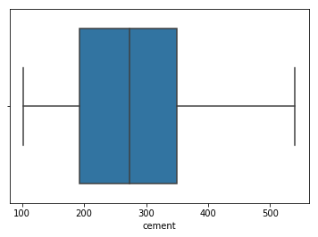

```python
sns.boxplot(conDF['cement'])
```

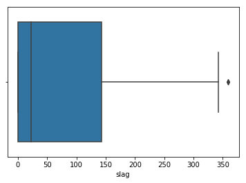

```python
sns.boxplot(conDF['slag'])
```

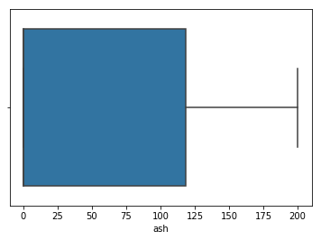

```python
sns.boxplot(conDF['ash'])
```

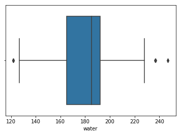

```python
sns.boxplot(conDF['water'])
```

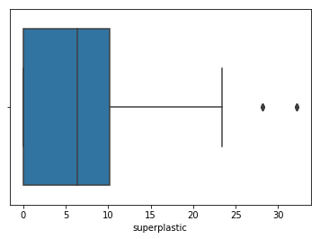

```python
sns.boxplot(conDF['superplastic'])
```

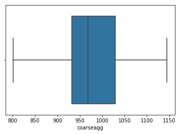

```python
sns.boxplot(conDF['coarseagg'])
```

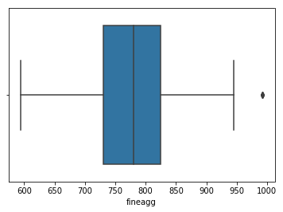

```python
sns.boxplot(conDF['fineagg'])
```

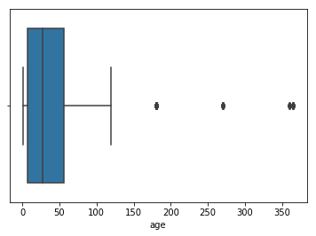

```python
sns.boxplot(conDF['age'])
```

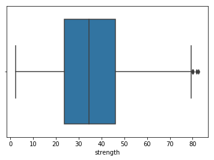

```python
sns.boxplot(conDF['strength'])
```